# ESM 204 HW 3

Hannah Brady and Janelle Gaun

5/6/2021

# Part 1

*One gallon of gasoline emits 19.6 pounds of CO<sub>2</sub>. Assuming that the interim Social COst of Carbon (SCC) correctly reflects the total social cost of one metric ton of CO<sub>2</sub>, what is the marginal externality cost (MEC) per gallon of gas?*

The Biden Administration’s “interim” value of the SCC is $51 per metric ton of CO2.

The MEC can be calculated as follows:

MEC<sub>gal</sub> = $51/metric ton CO<sub>2</sub> * (1 ton/ 2204.64 lbs) * (19.6 lb CO<sub>2</sub>/gal of gas) = $0.45 per gallon of gas

# Part 2

*What is the aggregate daily demand curve for gasoline? What is the supply curve for gasoline? What is the “benefit” to consumers under the status quo? What is the “benefit” to producers under the status quo? What is the environmental cost under the status quo?*

## Aggregate daily demand curve

Data provided includes price (in $) and quantity (in gallons) estimates of demand per day for “high” and “low” income groups.

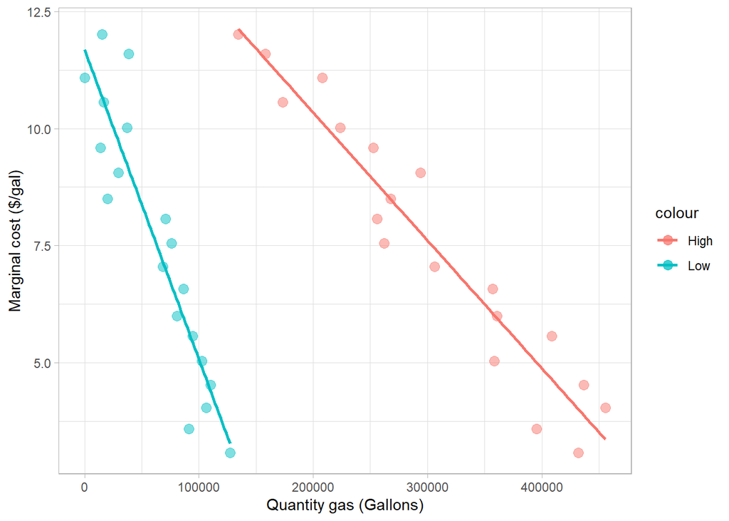

Data points are fit with a linear model to create the following estimates of demand curves by income group:

D<sub>low</sub> = -0.000066Q + 11.7

D<sub>high</sub> = -0.000027Q + 15.8

Aggregate demand curve is created by horizontally summing individual demand curves. This is done by solving each equation for Q, adding both equations together, and re-solving for P. The resulting equation is valid for the range of prices where both high and low consumers have demand. The aggregate demand equals the demand for the high demand consumer group at prices where only the high demand consumer group has demand:

D<sub>agg</sub> , P < 11.7 = -0.000019Q + 14.6

D<sub>agg</sub> , P > 11.7 = -0.000027Q + 15.8

## Supply Curve

We are given that:

- the current gas price (without any taxes) is $3.00 per gallon, i.e. P<sub>eq</sub> = $3/gal
- the marginal cost of producing a gallon of gasoline is linear
- MC has a price-intercept of 0, i.e. at Q = 0 gal, P = $0/gal

Solve for Q<sub>eq</sub> by solving for Q, given D<sub>agg</sub> = $3/gal:

Q<sub>eq</sub> = 600202 gallons of gasoline

Solve for slope: (rise/run) = (P<sub>eq</sub> - 0)/(Q<sub>eq</sub> - 0) = 0.000005

MC = 0.000005Q

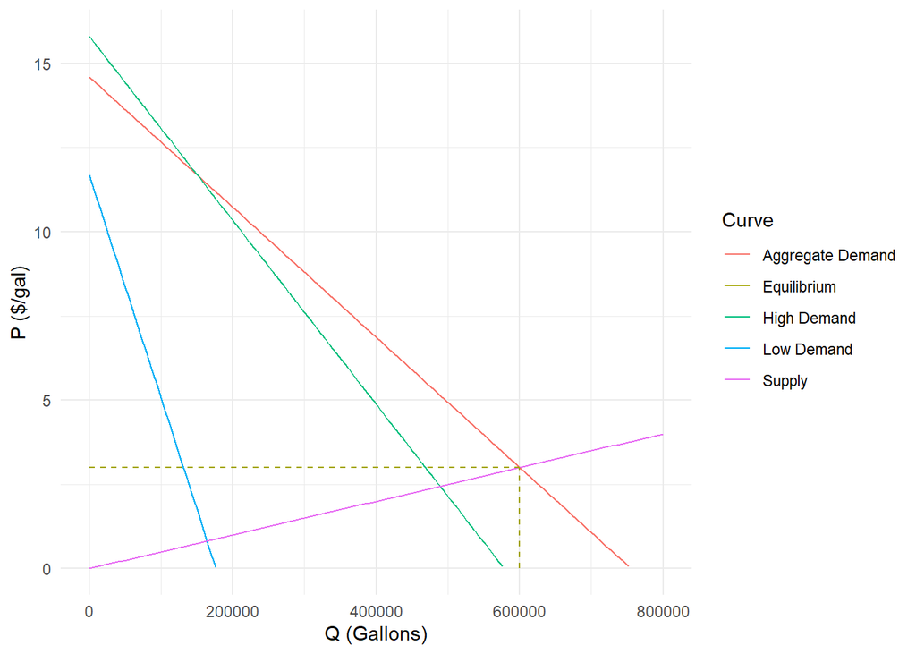

## Status quo benefits to producers and consumers

Consumer surplus is calculated by integrating under the aggregate demand curve from 0 to Q<sub>eq</sub> and the subtracting the cost of gasoline (P<sub>eq</sub>*Q<sub>eq</sub>):

Consumer surplus under status quo = $3571830.

Producer surplus is calculated by integrating under the supply curve to calculate cost of producing gas and subtracting that from total payment by consumers to producers for gasoline (P<sub>eq</sub>*Q<sub>eq</sub>):

Producer surplus under status quo = $900302.

## Environmental cost under status quo

Under the status quo, the total environmental cost is equal to:

Total Environmental Cost = MEC<sub>gal</sub> (from Part 1) * Total gallons of gas consumed by society (Q<sub>eq</sub>) = $0.45/gal * 600202 gal of gas = $272138.25

# Part 3

*How is the current consumer benefit divided between “high” and “low” income consumers?*

Use the demand curves for the high and low demand to solve for the quantities for each consumer group given the equilibrium price of $3/gal gas:

- Q<sub>[eq low]</sub> = 131371 gallons of gas purchased by low demand consumers
- Q<sub>[eq high]</sub> = 468831 gallons of gas purchased by high demand consumers

Calculate benefit to each consumer group by integrating under the demand curve from 0 to Q<sub>[eq of group]</sub> and then subtracting value of P<sub>eq</sub>*Q<sub>[eq of group]</sub>:

- Consumer surplus of low demand group = $570509
- Consumer surplus of high demand group = $3001322

# Part 4

*Derive the optimal gas tax (in $ per gallon of gasoline) using the interim SCC. Noting that recent research has shown the poor face a disproportionate share of the impacts from climate change, assume that the climate externality is borne entirely by the “low” income group. What would be the effects of this tax on:*

The optimal gas tax would be equal to the marginal external cost (MEC) from Part 1:

MEC = $0.45 per gallon of gas

#### a. The amount of gasoline produced and consumed

Find the marginal social cost of gasoline by vertically aggregating the marginal supply curve and the marginal external cost curves

```
MSC  = 0.000005Q + 0.45
```

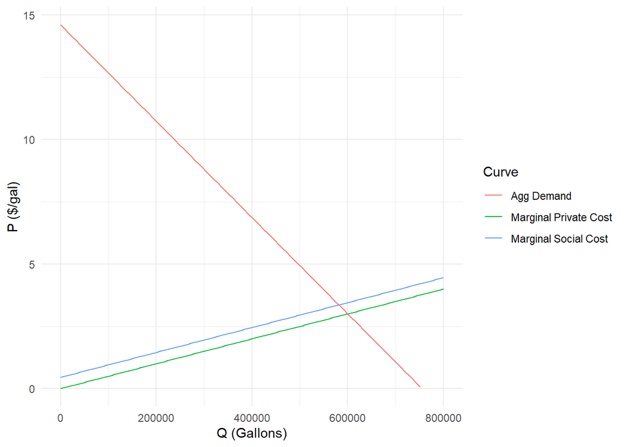

```
The tax results in a socially optimum equilibrium quantity of 581561.5 gallons of gas produced and consumed.
```

#### b. The price of gasoline

The new price of gasoline is found by solving the marginal social cost curve for P<sub>[socially optimal]</sub> given the socially optimal equilibrium quantity calculated in Part 4.a above:

Price<sub>[socially optimal]</sub> = 0.000005*581561.5 + 0.45= $ 3.36 /gal

#### c. Overall welfare of “high” income consumers

Calculate the welfare of “high” income consumer by determining the consumer surplus at the new equilibrium and subtracting the cost of purchasing gas

- Solve D<sub>high</sub> = -0.000027Q + 15.8 for Q, at the socially optimum equilibrium price $3.36/gal determined in Part 4.b above

  Q<sub>[SO high]</sub> = 455639.71 gallons
- Integrate “high” demand curve (-0.000027Q + 15.8) from 0 to 455639.71 then subtract the cost of purchasing gas ($3.36/gal*455639.71 gal)

  High demander welfare = $2834804.6

#### d. Overall welfare of “low” income consumers

Calculate the welfare to the low income group by determining the consumer surplus at the socially optimal equilibrium price and quantity. Additionally, because the “low” income group bears the entire cost of the negative externality, the total environmental cost of consuming gas by both income groups must also be subtracted from the low demanders consumer surplus.

- Solve D<sub>low</sub> = -0.000066Q + 11.69 for Q, at the socially optimum equilibrium price $3.36/gal determined in Part 4.b above

  Q<sub>[SO low]</sub> = 125921.8gallons
- Integrate “low” demand curve (-0.000066Q + 11.69) from 0 to 125921.8 then subtract the cost of purchasing gas ($3.36/gal*125921.8 gal) and the total cost of environmental damage from all of society’s gas consumption (MECxQ<sub>SO</sub>)

  Low demander welfare = $260478

#### e. Gas producers

Find the welfare of the producers by finding the total income generated at the socially optimal equilibrium and subtracting the tax revenue and the cost of production.

- Income = P<sub>SO</sub>*Q<sub>SO</sub> - tax revenue
- Cost: Integrate MPC curve (0.000005Q) from 0 to Q<sub>SO</sub> (581562 gal)
- Welfare: Income - Cost

Welfare = $ 845250.58

#### f. Total environmental damage

Total environmental damage is found by multiplying the MEC ($0.45 per gallon) by the quantity of gas consumed Q<sub>SO</sub> (581561.51) gallons

TED = $263686.66

#### g. Total tax revenue generated

Because the tax equals the MEC, tax revenue equals total environmental damage, which was found by multiplying the MEC/tax ($0.45 per gallon) by the quantity consumed Q<sub>SO</sub> (581561.51) gallons

Tax Revenue= $263686.66

# Part 5

*Now, assume that all revenue from the gas tax will be redistributed to the consumers in proportion to their pre-tax consumption of gas. For example, if 80% of the gas was consumed by “high” income consumers, then they get 80% of the tax revenue. Additionally, consider the fact that current scientific evidence suggests the true SCC may be much higher than $51. For a range of SCC values ($51, $75, $100, $125, and $150 per metric ton of CO<sub>2</sub>), calculate the effects of an SCC-based gasoline tax on overall welfare of “high” income consumers, overall welfare of “low” income consumers, and gas producers.*

Taxes are redistributed proportional to original consumption of gas between high and low income groups at the free market equilibrium price as determined in Part 3 above.

Proportion= Q<sub>group</sub>/Q<sub>total</sub>

- Percentage Consumed<sub>low</sub>= 22%
- Percentage Consumed<sub>high</sub>= 78%

First, the range of SCC values were converted to marginal external cost (MEC) of one gallon of gas using the same formula provided in Part 1 above. The MEC for each SCC value equals the SCC-based gasoline tax:

- $51/ton CO<sub>2</sub> results in an MEC/SCC-based gasoline tax of $0.45/gal
- $75/ton CO<sub>2</sub> results in an MEC/SCC-based gasoline tax of $0.67/gal
- $100/ton CO<sub>2</sub> results in an MEC/SCC-based gasoline tax of $0.89/gal
- $125/ton CO<sub>2</sub> results in an MEC/SCC-based gasoline tax of $1.11/gal
- $150/ton CO<sub>2</sub> results in an MEC/SCC-based gasoline tax of $1.33/gal

Second, the new marginal social cost curve for each level of tax was determined to be the Marginal Cost curve determined in Part 2 plus the SCC-based gasoline tax. For example, MSC<sub>[SCC = $100]</sub> = 0.000005Q + 0.89

Third, the socially optimal equilibrium quantity of gas sold was calculated by finding the intersection of the aggregate demand curve from Part 2 and the MSC.

Fourth, the total tax revenue generated by the tax was calculated by multiplying the socially optimal equilibrium quantity of gas sold that was determined above by the MEC. Then, the amount of tax revenue redistributed to each income group was calculated by multiplying the total tax revenue generated by the original “Percentage Consumed” of each income group determined above.

Fifth, the socially optimal price of gasoline was calculated by solving the total aggregate demand curve for P<sub>eq</sub> given the Q<sub>eq</sub> determined above.

Sixth, the quantity of gas purchased by each income group was determined by solving each group’s demand curve (determined in Part 2) given the P<sub>eq</sub> determined above.

Table 1

| SCC (USD/ton CO<sub>2</sub>) | Price of gas/gal | Total Q of gas sold (gal) | Q of gas sold (gal) to high demanders | Q of gas sold (gal) to low demanders |
| --- | --- | --- | --- | --- |
| 51 | 3.36 | 581,561.5 | 455,639.7 | 125,921.8 |
| 75 | 3.53 | 572,789.7 | 449,432.1 | 123,357.7 |
| 100 | 3.71 | 563,652.5 | 442,965.8 | 120,686.7 |
| 125 | 3.88 | 554,515.2 | 436,499.5 | 118,015.7 |
| 150 | 4.06 | 545,378.0 | 430,033.2 | 115,344.8 |

Seventh, welfare of each consumer group was determined by integrating each group’s demand curve from 0 to the quantity of gas consumed by the group given the MSC/SCC-based gasoline tax. Then the cost of purchasing the gas (P<sub>eq</sub>*Q<sub>eq</sub>) was subtracted from the integral value. For the low income group, total environmental damage was also subtracted from the integral. Lastly, tax revenue redistributed to each group was added. Results are shown in the table below.

Eighth, welfare to gas producers was calculated by multiplying the price of gas by the quantity sold and subtracting the tax revenue and the cost of production. Cost of production was determined as the integral of the marginal cost curve from 0 to the equilibrium quantity sold.

Table 2 (all values in USD unless otherwise noted)

| SCC (USD/ton CO<sub>2</sub>) | Tax revenue to high demanders | Welfare to high demanders | Tax revenue to low demanders | Total Environmental Damage | Welfare to low demanders | Welfare to gas producers |
| --- | --- | --- | --- | --- | --- | --- |
| 51 | 205,972 | 3,040,776 | 57,715 | 263,687 | 318,193 | 845,251 |
| 75 | 298,331 | 3,056,419 | 83,595 | 381,926 | 204,704 | 819,945 |
| 100 | 391,429 | 3,070,723 | 109,682 | 501,111 | 90,058 | 793,994 |
| 125 | 481,354 | 3,082,996 | 134,880 | 616,234 | -20,943 | 768,460 |
| 150 | 568,107 | 3,093,239 | 159,189 | 727,296 | -128,301 | 743,343 |

Notably, increased values of the SCC increases the value of total environmental damage. Because the low income group bears the entirety of the cost of the environmental damage, their welfare continuously decreases with increasing SCC. Even though the group receives 22% of the tax revenue generated as well as surplus from gas purchased, this is not enough to negate the cost of the environmental damage. Ultimately, at an SCC of $125 and $150, the welfare to the low income group is negative, indicating that the group experiences costs, rather than welfare, with this tax scheme. High income group welfare increases slightly with the increasing SCC while welfare to gas producers decreases slightly.

# Part 6

*Suppose a new electric car technology is invented but only the “high” income group has access to these expensive new cars. This lowers the gasoline demand curve for the “high” income group by half (vertically).*

Begin by deriving a new demand curve for the high income group.

Solve for a new y-intercept for the demand curve of high demanders by reducing the previous y-intercept (P = 15.8) by half. The slope for the new demand curve will remain the same (m = -0.000027) because elasticity of high demand has not changed, only the number of high demanders for gasoline has shifted.

The resulting new high income demand curve is D<sub>high-e</sub> = -0.000027*Q + 7.9

Use the new high income demand curve to generate a new aggregate demand curve by horizontally summing individual demand curves of low income group (unchanged) and new high income group demand. To sum horizontally, solve each equation for Q, add both equations together, and re-solve for P. The new high income demand curve is lower than the low income demand curve. This means that the aggregate demand equals the demand for the low income consumer group at prices where only the low demand consumer group has demand (i.e. the “kinked” portion of the new aggregate demand curve). The resulting aggregate demand curve when electric technology is introduced is therefore:

D<sub>agg-e</sub> , P < 7.9 = -0.000019*Q + 9.01

D<sub>agg-e</sub> , P > 7.9 = -0.000066Q + 11.7

#### (a) What is total gas consumption?

The new equilibrium quantity of gas is found by setting the aggregate demand curve with electric technology equal to the supply curve (unchanged from earlier parts) and solving for Q.

-0.000019* Q + 9.01 = 0.000005*Q

Q<sub>eq,e</sub> = 370315 gallons

#### (b) What is the total environmental externality?

Calculate the total environmental damage assuming the social cost of carbon is $51/ton of CO<sub>2</sub> emitted.

Total Environmental Damage = $167904.95

#### (c) What value of the gasoline tax makes the total environmental damage the same as the electric car technology?

Evaluate the original aggregate demand curve and the supply curve at the new equilibrium quantity determined in 6(a) to determine the marginal benefit and the marginal cost at Q<sub>e,eq</sub> = 370315 gal. The tax to ensure reduce environmental damage to the electric technology levels is the difference between of the marginal benefit and marginal cost curves at the quantity, Q<sub>e,eq</sub>.

Aggregate Demand: P =-0.000019*Q + 14.6

Supply: P =0.000005*Q

P<sub>d</sub>(370315)= $7.44

P<sub>s</sub>(370315)= $1.85

New Tax: $5.59

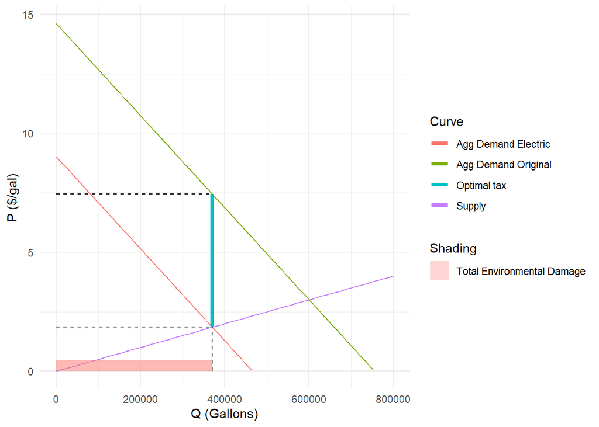